# Discutindo a discussão: Análise das fichas de avaliação

Pós-graduação do Instituto de Biociências - USP

Glauco Machado e Paulo Inácio Prado

27 maio, 2015

## Contexto

Este documento detalha as análises das fichas de avaliação de teses e dissertações do IB-USP, usadas em nossa palestra no workshop [Pensamento crítico do pós-graduando](http://www.ib.usp.br/images/workshop05.png).

Códigos das análises e os dados usados estão disponíveis no repositório GitHub que abriga esta página (https://github.com/CPG-IBUSP/discutindo-a-discussao). Correções, críticas e sugestões novas análises a acrescentar são muito bem vindas.

### A questão

Pouco mais da metade das teses e dissertações defendidas no IB-USP entre 2011 e 2014 tiveram sua discussão indicada como excelente ou muito boa pelos membros das bancas de defesa. Isso torna a discussão o pior entre os dez itens avaliados (Fig.1).

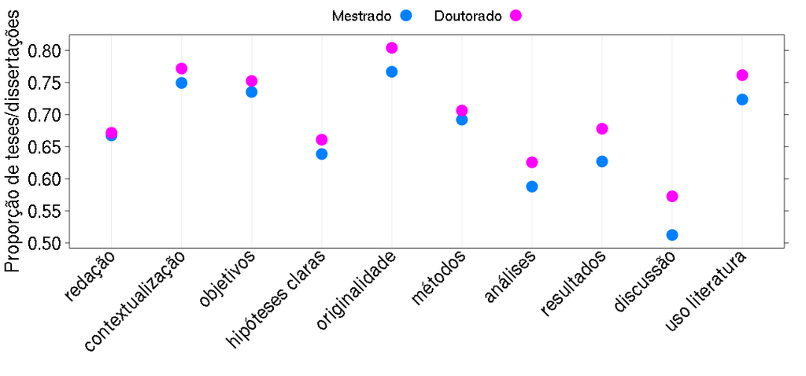

**Figura 1 - Proporção de teses e dissertações consideradas excelentes em dez quesitos pelos membros das banca de defesa.** Avaliação anônima feita pelos participantes das bancas de defesa, que indicaram até dez aspectos em que a tese/dissertação foi excelente ou muito boa: redação, contextualização teórica, objetivos bem definidos, pergunta/hipóteses claras, originalidade e relevância, métodos bem descritos e adequados, análises bem descritas e adequadas, resultados bem apresentados e conclusivos, discussão lógica e bem fundamentada, uso adequado da literatura. Fonte: [Avaliação de teses e dissertações do IB, CPG](http://cpg-ibusp.github.io/avaliacao-teses/)

As seções seguintes usam os outros dados levantados pela ficha de avaliação para testar algumas hipóteses para este padrão.

## A qualidade da discussão depende do curso, título, tempo ou avaliação dos outros itens ?

A probabilidade da discussão ser considerada excelente foi afetada inequivocamente apenas pela avaliação dos demais itens da tese.

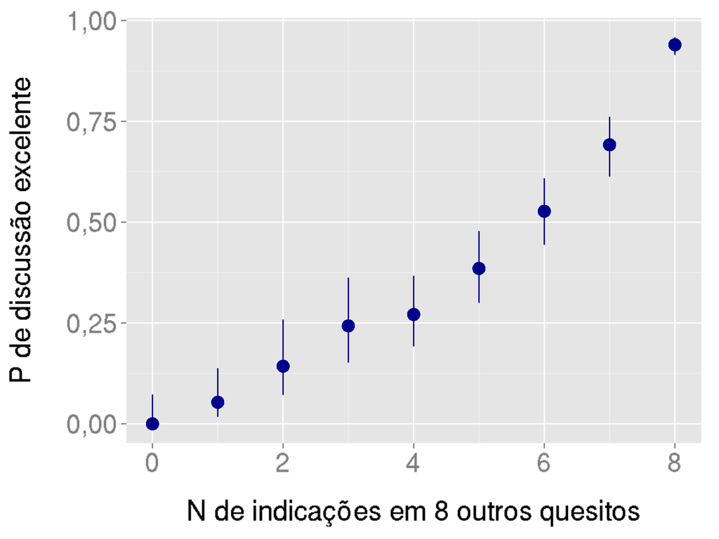

**Figura 2 - Proporção de teses e dissertações consideradas excelentes na discussão em função de sua avaliação nos demais quesitos.** O eixo x é o número de indicações nos demais quesitos avaliados com a ficha. O eixo y é a proporção de teses e dissertações que tiveram a discussão indicada como excelente (pontos) e os intervalos de confiança 95% (barras) do previsto pela ponderação de modelos selecionados (veja em métodos, a seguir). Tamanho da amostra: 1305 avaliações de 491 teses e dissertações.

### Métodos

Ajustamos modelos binomiais com efeitos mistos (glmms) em que variável resposta foi a indicação ou não de excelência da discussão por cada avaliador. Foram ajustados modelos com todas as combinações aditivas dos seguintes efeitos fixos, disponíveis na ficha:

- `titulo`: fator com dois níveis (mestrado ou doutorado)
- `programa`: fator com cinco níveis (Botânica, Ecologia, Fisiologia, Genética, Zoologia)
- `atrasou` : fator com dois níveis (depósito ocorreu em até 10% a mais que o prazo máximo, ou depósito com atraso superior a 10% do prazo máximo)
- `nota8` : numérico (soma de indicações de excelência nos demais itens, exceto originalidade)

Em todos os modelos cada tese foi tratada como efeito aleatório. Isso significa que o modelo leva em conta a associação entre avaliações de uma mesma tese ou dissertação.

A seleção de modelos com $\Delta\textrm{AIC}$ corrigido para pequenas amostras indicou 3 modelos plausíveis:

```
##                                       dAICc df weight
## ~ nota8                                 0.0 3  0.3553
## ~ titulo + nota8                        0.3 4  0.3135
## ~ atrasou + nota8                       2.0 4  0.1300
## ~ titulo + nota8 + atrasou              2.1 5  0.1269
## ~ titulo + titulo:atrasou + nota8       4.1 6  0.0463
## ~ titulo + programa + nota8             7.1 8  0.0102
## ~ programa + nota8                      7.2 7  0.0099
## ~ titulo + programa + atrasou + nota8   8.9 9  0.0042
## ~ nota8 + programa + atrasou            9.2 8  0.0036
## ~ titulo                              593.5 3  <0.001
## ~ titulo + atrasou                    595.5 4  <0.001
## ~1                                    596.0 2  <0.001
## ~ atrasou                             597.4 3  <0.001
## ~ titulo + programa                   600.4 7  <0.001
## ~ titulo + programa + atrasou         602.5 8  <0.001
## ~ programa                            602.6 6  <0.001
## ~ programa + atrasou                  604.1 7  <0.001
```

Uma inspeção dos coeficientes mostrou que os efeitos do tempo de depósito e do título eram fracos e com erros-padrão muito altos. Ainda assim, foram calculados os previstos pela ponderação dos três modelos (model averaging). A barra de erro na Fig.2 é o intervalo de confiança destas previsões. A inspeção gráfica confirmou que o único efeito relevante foi o da nota obtida nos demais quesitos.

## Orientadores avaliam a qualidade da discussão diferente do resto da banca ?

A avaliação que os orientadores fizeram da discussão foi diferente da feita pelo resto da banca. Mas a direção desta diferença dependeu da avaliação que o orientador fez dos outros itens (Fig.3).

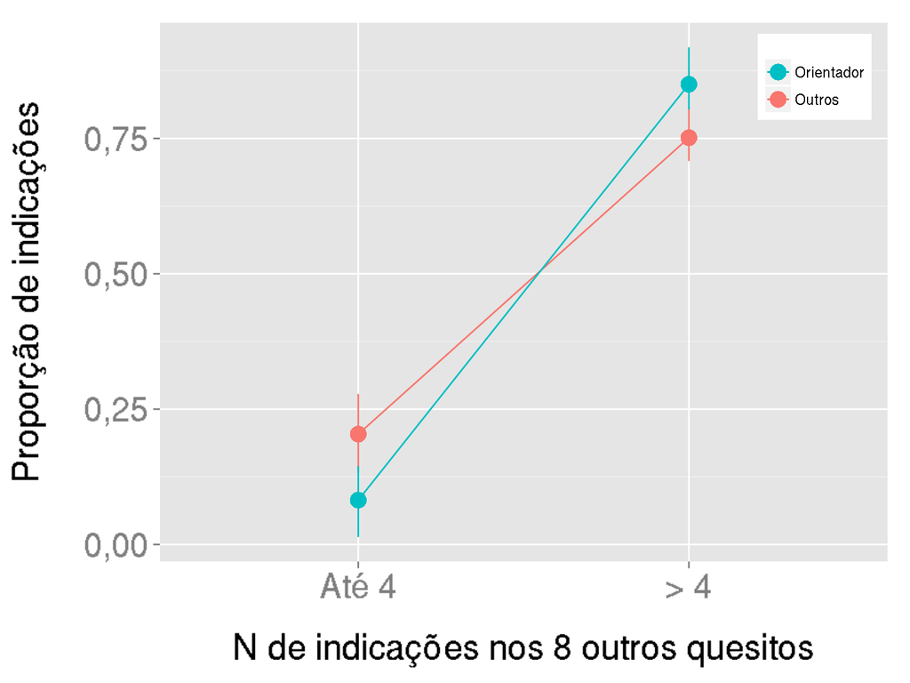

**Figura 3 - Proporção de teses e dissertações consideradas excelentes na discussão pelos orientadores e pelos outros avaliadores, em função de sua avaliação nos demais quesitos.** O eixo x é o número de indicações nos demais quesitos avaliados com a ficha, exceto originalidade. O eixo y é a proporção de teses e dissertações que tiveram a discussão indicada como excelente (pontos) e os intervalos de confiança 95% (barras) do previsto pelo modelo selecionado (veja em métodos, a seguir). Tamanho da amostra: 744 avaliações de 201 teses e dissertações.

Quando o orientador indica excelência nos demais itens, a chance de que indique excelência para a discussão é 13 % maior que os demais avaliadores. Já quando o orientador indicou poucos dos demais quesitos, a chance de que indique que a discussão é excelente é 64% menor do que os dos demais avaliadores.

### Métodos

A partir de 2013 os orientadores foram solicitados a também preencher a ficha de avaliação. Para esta análise usamos as 744 fichas de 201 teses e dissertações que tiveram esta avaliação dos orientadores, e de outros membros da banca.

Usamos modelos binomiais com efeitos mistos (glmms) para verificar se a probabilidade da discussão ser considerada excelente difere entre orientador e os demais membros da banca. Em todos os modelos as teses/dissertações foram incluídass como efeito aleatórios, para considerar a relação entre avaliações de um mesmo trabalho. As variáveis usadas como efeitos fixos foram:

- `titulo`: fator com dois níveis (mestrado ou doutorado)
- `orientador`: fator com dois níveis (o avaliador é o orientador; ou o avaliador não é o orientador)
- `nota.m4` : fator com dois níveis (até 4 indicações de excelência nos demais itens exceto originalidade; mais de 4 indicações)

Em todos os modelos mantivemos o efeito da avaliação dos outros itens, que na análise anterior mostrou forte influência sobre a avaliação da discussão. Esta variável foi simplificada em fator com duas classes, devido ao menor número de fichas para esta análise. Para avaliar se o rigor de avaliação do orientador mudava entre mestrados e doutorados, também incluímos esta covariável como candidata, com efeito aditivo e em interação com o avaliador. Por fim, a exploração dos dados sugeriu que poderia haver uma interação entre o tipo de avaliador (orientador ou não) e a avaliação nos outros quesitos. Por isso também ajustamos um modelo com esta interação.

O modelo com a interação entre orientador e avaliação dos outros quesitos foi muito mais plausível que os demais.

```
##                                                     dAICc df weight
## ~ orientador + nota.m4 + orientador:nota.m4          0.0  5  0.9769
## ~ 1                                                  8.9  3  0.0114
## ~ orientador + nota.m4                               9.7  4  0.0077
## ~ orientador + titulo + nota.m4                     11.6  5  0.0030
## ~ orientador + titulo + orientador:titulo + nota.m4 13.6  6  0.0011
```

As barras na Fig.3 são os intervalos de confiança empíricos a 95% calculados por simulações bootstrap dos previstos pelo modelo mais plausível, levando em conta as fontes de variação dos efeitos fixos e aleatórios.

## A qualidade da discussão afeta o impacto potencial do trabalho ?

No entender dos avaliadores, uma boa discussão aumenta muito o impacto potencial dos artigos que podem resultar da tese ou dissertação. Essa relação é exacerbada por bons resultados Fig.4.

Para os trabalhos que receberam mais de 4 indicações de excelência nos outros itens, a probabilidade de indicação de impacto alto é 77% maior quando o avaliador considerou a discussão excelente. Esta diferença sobe para 142 % quando os resultados e a discussão foram considerados excelentes. Também chama a atenção que menos de um terço dos trabalhos sem indicação de excelência para discussão e resultados tiveram indicação de alto impacto potencial, independente da indicação nos outros quesitos.

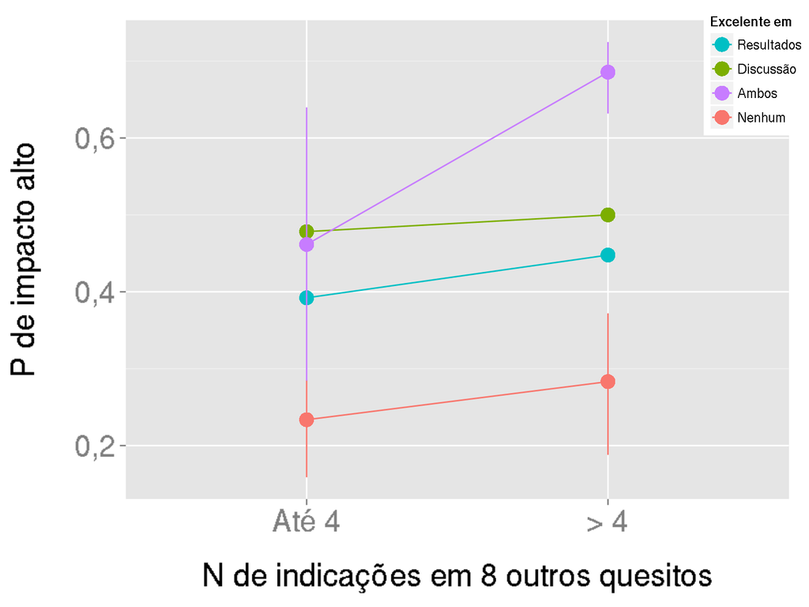

**Figura 4 - Proporção de teses e dissertações consideradas de alto impacto potencial, em função de sua avaliação nos demais quesitos.** As linhas são os subconjuntos de fichas com indicação de excelência em discussão, resultados, ambos ou nenhum. O eixo x é o número de indicações nos demais quesitos avaliados com a ficha, incluindo originalidade. O eixo y é a proporção de teses e dissertações que tiveram indicação de impacto potencial alto (pontos) e os intervalos de confiança 95% (barras) do previsto pelo modelo selecionado (veja em métodos, a seguir). Tamanho da amostra: 1238 avaliações de 483 teses e dissertações.

### Métodos

Usamos modelos binomiais com efeitos mistos (glmms) para verificar se a probabilidade do avaliador indicar impacto alto depende do avaliador ter indicado que a discussão é excelente. Uma análise exploratória sugeriu que a indicação de excelência dos resultados poderia afetar esta probabilidade. Por isso, incluímos também este efeito nos modelos. Também incluímos nos modelos a soma das indicações de excelência nos demais quesitos (incluindo originalidade), dado o forte efeito detectado nas análises anteriores. Em todos os modelos os alunos foram incluídos como efeito aleatórios, para considerar a variação entre avaliações a um mesmo trabalho, entre avaliadores. As variáveis usadas como efeitos fixos foram:

- `D`: avaliação da discussão, fator com dois níveis (indicado como excelente ou não)
- `R`: avaliação dos resultados, fator com dois níveis (indicado como excelente ou não)
- `N` : soma das indicações nos outros oito quesitos, numérico.

Os dois modelos com efeito aditivo da avaliação da discussão e dos resultados foram igualmente plausíveis.

```
##                     dAICc df weight
## ~ D + R + N + D:R:N  0.0  8  0.534
## ~ D + R + N          0.5  5  0.422
## ~ D + N              5.0  4  0.045
## ~ R + N             23.0  4  <0.001
## ~ 1                 36.3  3  <0.001
```

As barras na Fig.4 são os intervalos de confiança de simulações bootstrap. Simulamos 1000 vezes os previstos para cada ficha para cada modelo e então calculamos os intervalos de confiança empíricos a 95% de cada modelo. As barras indicam o mínimo dos limites inferiores e o máximo dos limite superiores destes dois intervalos e, portanto são um limite conservador da combinação dos dois modelos.

## Agradecimentos

- A todos participantes das 491 bancas de defesa que ocorreram no IB desde 2011, pelo tempo e atenção concedidos à avaliação de nossas teses e dissertações.
- À toda equipe da seção de Pós-Graduação do IB, cujo compromisso institucional tornou possível esta avaliação. A aplicação, organização e transcrição dos dados de centenas de fichas por ano não seria possível sem isso.
- A todos os professores, estudantes e funcionários do IB pelas contribuições nas ocasiões em que apresentamos estes resultados para debate.
- Ao Carlos Navas e Paulo Sano, por criar o Simpósio “Pensamento Crítico na Pós-Graduação”, e por nos convidar a participar.
- A todos de nosso co-laboratório LAGE, por tantas discussões intensas e produtivas sobre ciência, pós-graduação, a vida, o universo e tudo mais.
- À FAPESP pelo continuado apoio à nossa pesquisa e ao CNPq pelas nossas bolsas de produtividade.